# Text Analysis and Novels

# Text Analysis of Novels

[figure not shown]

[figure not shown]

Although I like reading books, unfortunately I don’t find much time to read. However, I found that NLP is giving an opportunity to learn more about novels without reading it. My idea here is to try to learn as much as possible about two novels, *The Aspern Papers* and *Awakening*.

## Data

Downloading Novels ‘The Awakening’ and ‘The Aspern Papers’

```r
awakening <- scan("http://www.gutenberg.org/files/160/160-0.txt", what="character", blank.lines.skip = TRUE, sep="\n")
```

```
Read 6088 items
```

```r
aspern <- scan("http://www.gutenberg.org/files/211/211-0.txt", what="character", blank.lines.skip = TRUE, sep="\n")
```

```
Read 3531 items
```

```r
awakening<- iconv(awakening, 'utf-8', 'ascii', sub='')
aspern<- iconv(aspern, 'utf-8', 'ascii', sub='')
```

## Text cleaning

Cleaning headers of the two novels.

```r
# Awakening: cleaning headers
awakening.begin <- which(awakening=="THE AWAKENING")[2]
awakening.end   <- which(awakening=="*****") - 1
awakening.v<- awakening[awakening.begin:awakening.end]
```

```r
# Aspern: cleaning headers
aspern.begin <- which(aspern=="Macmillan and Co., 1888.")+1
aspern.end   <- which(aspern=="End of the Project Gutenberg EBook of The Aspern Papers, by Henry James") - 1
aspern.v <- aspern[aspern.begin:aspern.end]
head(aspern.v)
```

```
[1] "I"
[2] "I had taken Mrs. Prest into my confidence; in truth without her I"
[3] "should have made but little advance, for the fruitful idea in the whole"
[4] "business dropped from her friendly lips. It was she who invented the"
[5] "short cut, who severed the Gordian knot. It is not supposed to be the"
[6] "nature of women to rise as a general thing to the largest and most"
```

## Text preprocessing

Cutting in chapters and corpus creation:

```r
# Cutting the Awakening in chapters
awakening.v <- gsub("^I*(X|V)*I*$", "@@@", awakening.v)
awakening.string <- paste(awakening.v, collapse = " ")
awakening.chapters <- strsplit(awakening.string, "@@@ ")

# Cutting the Aspern in chapters
aspern.v <- gsub("^I*(X|V)*I*$", "@@@", aspern.v)
aspern.string <- paste(aspern.v, collapse = " ")
aspern.chapters <- strsplit(aspern.string, "@@@ ")
```

```r
# Awakening corpus creation
awakening.df <- as.data.frame(awakening.chapters, stringsAsFactors = FALSE)
awakening.df <-awakening.df[2:38,1]
awakening.df <- as.data.frame(awakening.df)
colnames(awakening.df) <- "chapters"
awakening.docs <- Corpus(VectorSource(awakening.df$chapters))

# Aspern corpus creation
aspern.df <- as.data.frame(aspern.chapters, stringsAsFactors = FALSE)
aspern.df <-aspern.df[2:38,1]
aspern.df <- as.data.frame(aspern.df)
colnames(aspern.df) <- "chapters"
aspern.docs <- Corpus(VectorSource(aspern.df$chapters))
```

Text pre-processing: removing unnecessary simbols and signs, converting letters to lower case, removing numbers, punctuation and white space.

```r
# Awakening: Text pre-processing
toSpace <- content_transformer(function (x , pattern ) gsub(pattern, " ", x))
awakening.docs <- tm_map(awakening.docs, toSpace, "/")
awakening.docs <- tm_map(awakening.docs, toSpace, "@")
awakening.docs <- tm_map(awakening.docs, toSpace, "\\|")
awakening.docs <- tm_map(awakening.docs, content_transformer(tolower))
awakening.docs <- tm_map(awakening.docs, removeNumbers)
awakening.docs <- tm_map(awakening.docs, removeWords, stopwords("english"))
awakening.docs <- tm_map(awakening.docs, removePunctuation)
awakening.docs <- tm_map(awakening.docs, stripWhitespace)

# Aspern: Text pre-processing
toSpace <- content_transformer(function (x , pattern ) gsub(pattern, " ", x))
aspern.docs <- tm_map(aspern.docs, toSpace, "/")
aspern.docs <- tm_map(aspern.docs, toSpace, "@")
aspern.docs <- tm_map(aspern.docs, toSpace, "\\|")
aspern.docs <- tm_map(aspern.docs, content_transformer(tolower))
aspern.docs <- tm_map(aspern.docs, removeNumbers)
aspern.docs <- tm_map(aspern.docs, removeWords, stopwords("english"))
aspern.docs <- tm_map(aspern.docs, removePunctuation)
aspern.docs <- tm_map(aspern.docs, stripWhitespace)
```

## Word analysis

Creation of a WordCloud:

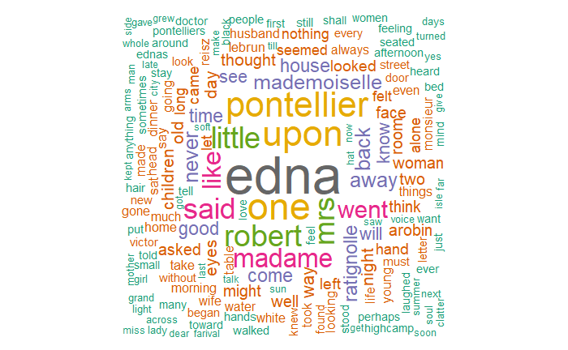

```r
# Awakening: Wordcloud
awakening.dtm <- DocumentTermMatrix(awakening.docs, control=list(weighting=weightTf))
awakening.m <- as.matrix(t(awakening.dtm))
awakening_v <- sort(rowSums(awakening.m),decreasing=TRUE)
awakening.d <- data.frame(word = names(awakening_v),freq=awakening_v)
set.seed(1234)
wordcloud(words = awakening.d$word, freq = awakening.d$freq, min.freq = 1,
          max.words=200, random.order=FALSE, rot.per=0.35,
          colors=brewer.pal(8, "Dark2"))

# Aspern: Wordcloud
aspern.dtm <- DocumentTermMatrix(aspern.docs, control=list(weighting=weightTf))
aspern.m <- as.matrix(t(aspern.dtm))
aspern_v <- sort(rowSums(aspern.m),decreasing=TRUE)
aspern.d <- data.frame(word = names(aspern_v),freq=aspern_v)
set.seed(1234)
par(mar = rep(0, 4))
```

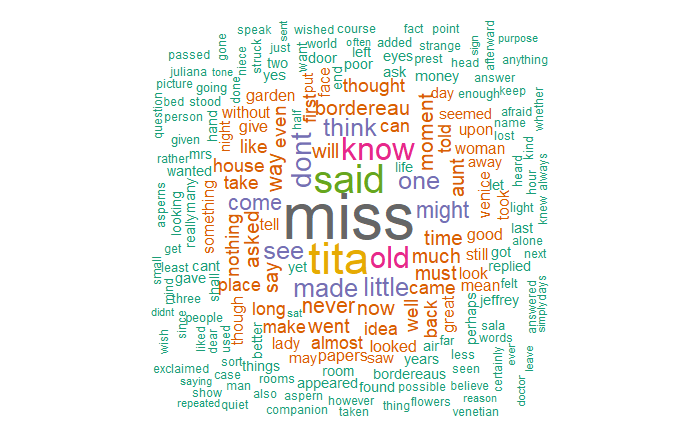

```r
wordcloud(words = aspern.d$word, freq = aspern.d$freq, min.freq = 1,
          max.words=200, random.order=FALSE, rot.per=0.35,
          colors=brewer.pal(8, "Dark2"))
```

## Commonality cloud and Comparison cloud

Creation of a corpus out of the both texts:

```r
cc.docs <- Corpus(VectorSource(c(awakening.string,aspern.string)))
```

Text pre-processing of the new corpus:

```r
toSpace <- content_transformer(function (x , pattern ) gsub(pattern, " ", x))
cc.docs <- tm_map(cc.docs, toSpace, "/")
```

```
transformation drops documents
```

```r
cc.docs <- tm_map(cc.docs, toSpace, "@")
```

```
transformation drops documents
```

```r
cc.docs <- tm_map(cc.docs, toSpace, "\\|")
```

```
transformation drops documents
```

```r
cc.docs <- tm_map(cc.docs, content_transformer(tolower))
```

```
transformation drops documents
```

```r
cc.docs <- tm_map(cc.docs, removeNumbers)
```

```
transformation drops documents
```

```r
cc.docs <- tm_map(cc.docs, removeWords, stopwords("english"))
```

```
transformation drops documents
```

```r
cc.docs <- tm_map(cc.docs, removePunctuation)
```

```
transformation drops documents
```

```r
cc.docs <- tm_map(cc.docs, stripWhitespace)
```

```
transformation drops documents
```

Comparison and Commonality cloud:

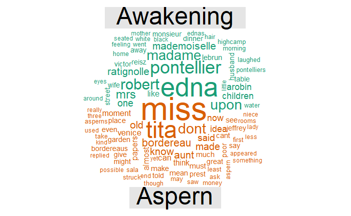

```r
cc.dtm <- DocumentTermMatrix(cc.docs)
cc.m <- as.matrix(t(cc.dtm))
colnames(cc.m)<- c("Awakening","Aspern")
#Comparison cloud
par(mar = rep(0, 4))
comparison.cloud(cc.m,max.words = 100,min.frrandom.order=FALSE)
# Commonality cloud
par(mar = rep(0, 4))
```

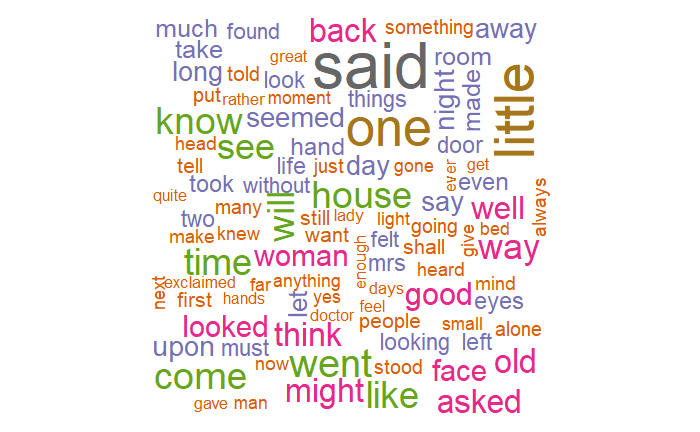

```r
commonality.cloud(cc.m,max.words = 100,colors = brewer.pal(8, "Dark2"),min.frrandom.order=FALSE)
```

## Sentiment timeline

Loading in relevant lexicons:

```r
library(tidytext)
library(dplyr)
library(tidyr)
library(plotly)
library(ggthemes)
library(sentimentr)
library(syuzhet)
data("sentiments")
afinn <- get_sentiments("afinn")
bing <- get_sentiments("bing")
loughran <- get_sentiments("loughran")
nrc <- get_sentiment_dictionary('nrc', language = "english")
```

Polarity timeline of Awakening:

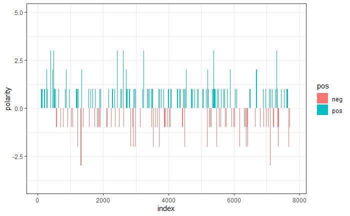

```r
sent.awakening <- readLines("http://www.gutenberg.org/files/160/160-0.txt")
sent.awakening <-iconv(sent.awakening, 'utf-8', 'ascii', sub='')
awakening.corpus <- VCorpus(VectorSource(sent.awakening))
awakening.corpus <- tm_map(awakening.corpus, content_transformer(tolower))
awakening.corpus <- tm_map(awakening.corpus, removeNumbers)
awakening.corpus <- tm_map(awakening.corpus, removeWords, stopwords("english"))
awakening.corpus <- tm_map(awakening.corpus, removePunctuation)
awakening.corpus <- tm_map(awakening.corpus, stripWhitespace)
awakening.dtm <- DocumentTermMatrix(awakening.corpus)
awakening.tidy <- tidy(awakening.dtm)
awakening.tidy$count <-as.numeric(awakening.tidy$count)
colnames(awakening.tidy)[2]<- 'word'
awakening.tidy$document <- as.numeric(awakening.tidy$document)
nrc.joy <- subset(nrc, nrc$sentiment=="joy")
joy.words <- inner_join(awakening.tidy, nrc.joy)
joy.words <- count(joy.words, word)

bing <- get_sentiments("bing")
awakening.sentiment <- inner_join(awakening.tidy, bing)
awakening.sentiment <- count(awakening.sentiment, sentiment, index=document)
awakening.sentiment <- spread(awakening.sentiment, sentiment, n, fill=0)
awakening.sentiment$polarity <- awakening.sentiment$positive - awakening.sentiment$negative
awakening.sentiment$pos <- ifelse(awakening.sentiment$polarity >=0, "pos", "neg")
ggplot(awakening.sentiment, aes(x=index, y=polarity, fill=pos))+geom_bar(stat="identity", position="identity", width=1)+
  theme_bw()
```

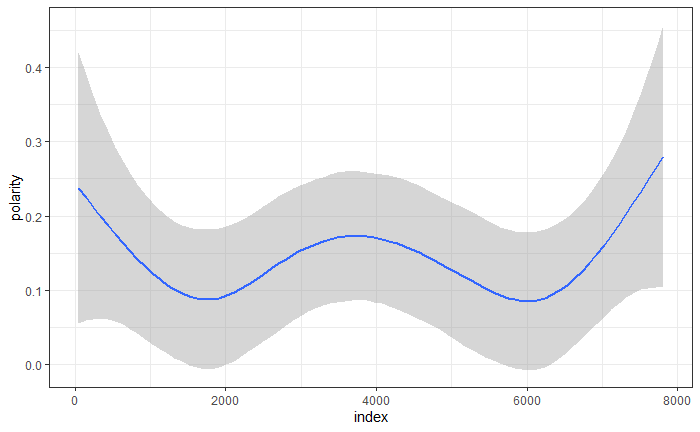

```r
awakening.smooth <- ggplot(awakening.sentiment, aes(index, polarity))+
  theme_bw()
(p2<-awakening.smooth + stat_smooth())
```

```r
NA
NA
```

Polarity timeline of Aspern:

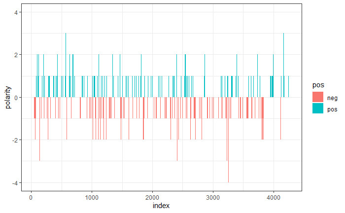

```r
sent.aspern <- readLines("http://www.gutenberg.org/files/211/211-0.txt")
aspern.corpus <- VCorpus(VectorSource(sent.aspern))
aspern.corpus <- tm_map(aspern.corpus, content_transformer(tolower))
aspern.corpus <- tm_map(aspern.corpus, removeNumbers)
aspern.corpus <- tm_map(aspern.corpus, removeWords, stopwords("english"))
aspern.corpus <- tm_map(aspern.corpus, removePunctuation)
aspern.corpus <- tm_map(aspern.corpus, stripWhitespace)
sent.aspern <-iconv(sent.aspern, 'utf-8', 'ascii', sub='')
aspern.dtm <- DocumentTermMatrix(aspern.corpus)
aspern.tidy <- tidy(aspern.dtm)
aspern.tidy$count <-as.numeric(aspern.tidy$count)
colnames(aspern.tidy)[2]<- 'word'
aspern.tidy$document <- as.numeric(aspern.tidy$document)
nrc.joy <- subset(nrc, nrc$sentiment=="joy")
joy.words <- inner_join(aspern.tidy, nrc.joy)
joy.words <- count(joy.words, word)

#bing <- subset(sentiments, sentiments$lexicon=='bing')[,-4]
aspern.sentiment <- inner_join(aspern.tidy, bing)
aspern.sentiment <- count(aspern.sentiment, sentiment, index=document)
aspern.sentiment <- spread(aspern.sentiment, sentiment, n, fill=0)
aspern.sentiment$polarity <- aspern.sentiment$positive - aspern.sentiment$negative
aspern.sentiment$pos <- ifelse(aspern.sentiment$polarity >=0, "pos", "neg")
ggplot(aspern.sentiment, aes(x=index, y=polarity, fill=pos))+geom_bar(stat="identity", position="identity", width=1)+theme_bw()
```

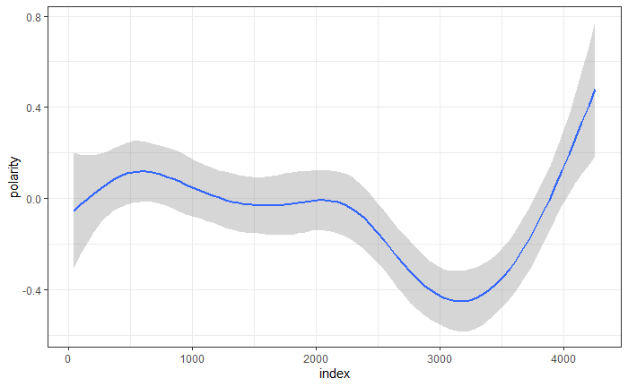

```r
aspern.smooth <- ggplot(aspern.sentiment, aes(index, polarity))+
  theme_bw()
(p3<-aspern.smooth + stat_smooth())
```

```r
g2 <- ggplotGrob(p2)
g3 <- ggplotGrob(p3)
g <- rbind(g2, g3, size = "first")
g$widths <- unit.pmax(g2$widths, g3$widths)
grid.newpage()
```

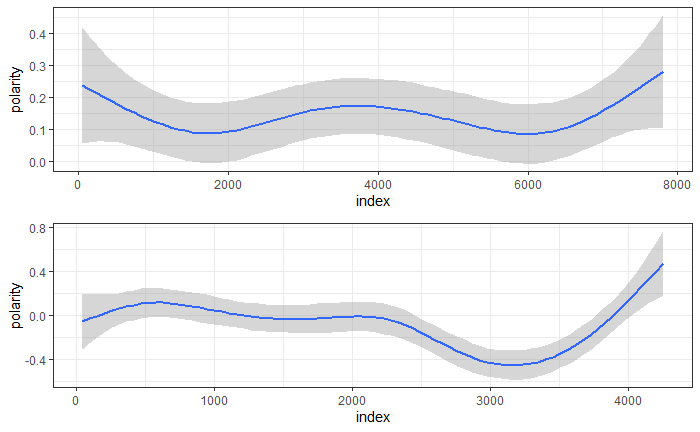

```r
grid.draw(g)
```

## Topic Modelling: LDA

Pick up 5 topics and try to make sense of the topics giving a label to them.

```r
# Awakening
top.mod.awakening.dtm <- DocumentTermMatrix(awakening.corpus, control = list(weighting=weightTf))
burnin = 1000
iter = 1000
keep = 50
set.seed(510)
top.mod.awakening.n <- nrow(top.mod.awakening.dtm)
top.mod.awakening.dtm <- top.mod.awakening.dtm[row_sums(top.mod.awakening.dtm > 0) > 1,]
top.mod.awakening.lda_basic.model<- LDA(top.mod.awakening.dtm, k = 5L, method = "Gibbs",
                      control = list(burnin = burnin, iter = iter, keep = keep, alpha = 1) )
top.mod.awakening.lda.topics <- as.matrix(topics(top.mod.awakening.lda_basic.model))
#top.mod.awakening.lda.topics
top.mod.awakening.lda.terms <- as.matrix(terms(top.mod.awakening.lda_basic.model, 10))
top.mod.awakening.lda.terms<- iconv(top.mod.awakening.lda.terms, 'utf-8', 'ascii', sub='')
#top.mod.awakening.lda.terms
awakening.top10termsPerTopic <- terms(top.mod.awakening.lda_basic.model, 10)
awakening.top10termsPerTopic <- iconv(top.mod.awakening.lda.terms, 'utf-8', 'ascii', sub='')
#awakening.top10termsPerTopic
colnames(awakening.top10termsPerTopic)<-c("Edna in her house/room"," Work, life and love - Leaving the papers after he/she died","Madame Edna - Mademoiselle Ratignolle - Robert","Emotions - Description of a face ","Mrs.Pontellier - Edna - Robert")
awakening.top10termsPerTopic
```

```
      Edna in her house/room  Work, life and love - Leaving the papers after he/she died
 [1,] "one"                  "project"
 [2,] "like"                 "work"
 [3,] "never"                "must"
 [4,] "thought"              "gutenbergtm"
 [5,] "day"                  "without"
 [6,] "might"                "new"
 [7,] "seemed"               "found"
 [8,] "children"             "many"
 [9,] "two"                  "feeling"
[10,] "felt"                 "full"
      Madame Edna - Mademoiselle Ratignolle - Robert Emotions - Description of a face
 [1,] "upon"                                         "little"
 [2,] "eyes"                                         "madame"
 [3,] "face"                                         "went"
```

[output cut: 18 more lines]

```r
awakening.topicNames <- apply(awakening.top10termsPerTopic, 2, paste, collapse=" ")
#awakening.topicNames
```

```r
# Aspern
top.mod.aspern.dtm <- DocumentTermMatrix(aspern.corpus, control = list(weighting=weightTf))
burnin = 1000
iter = 1000
keep = 50
set.seed(510)
top.mod.aspern.n <- nrow(top.mod.aspern.dtm)
top.mod.aspern.dtm <- top.mod.aspern.dtm[row_sums(top.mod.aspern.dtm > 0) > 1,]
top.mod.aspern.lda_basic.model<- LDA(top.mod.aspern.dtm, k = 5L, method = "Gibbs",
                                        control = list(burnin = burnin, iter = iter, keep = keep, alpha = 1) )
top.mod.aspern.lda.topics <- as.matrix(topics(top.mod.aspern.lda_basic.model))
#top.mod.aspern.lda.topics
top.mod.aspern.lda.terms <- as.matrix(terms(top.mod.aspern.lda_basic.model, 10))
top.mod.aspern.lda.terms<- iconv(top.mod.aspern.lda.terms, 'utf-8', 'ascii', sub='')
#top.mod.aspern.lda.terms

aspern.top10termsPerTopic <- terms(top.mod.aspern.lda_basic.model, 10)
aspern.top10termsPerTopic <- iconv(top.mod.aspern.lda.terms, 'utf-8', 'ascii', sub='')
#aspern.top10termsPerTopic
colnames(aspern.top10termsPerTopic)<-c("Home - Seeing somebody - description of eyes - leaving","Jeffrey","Tita","Aunt","Time - Woman - Venice")
aspern.top10termsPerTopic
```

```
      Home - Seeing somebody - description of eyes - leaving Jeffrey       Tita        Aunt
 [1,] "went"                                                 "project"     ""          "might"
 [2,] "came"                                                 "gutenbergtm" "miss"      "come"
 [3,] "house"                                                "work"        ""          "little"
 [4,] "back"                                                 "papers"      "tita"      "way"
 [5,] "face"                                                 "may"         "said"      "aunt"
 [6,] "looked"                                               "almost"      "know"      "even"
 [7,] "took"                                                 "works"       "dont"      "take"
 [8,] "away"                                                 "electronic"  "think"     "make"
 [9,] "look"                                                 "jeffrey"     "oh"        "idea"
[10,] "put"                                                  "aspern"      "bordereau" "told"
      Time - Woman - Venice
 [1,] "old"
 [2,] "one"
 [3,] "made"
 [4,] "never"
 [5,] "time"
 [6,] "long"
 [7,] "great"
 [8,] "still"
 [9,] "woman"
[10,] "upon"
```

```r
#aspern.topicNames <- apply(aspern.top10termsPerTopic, 2, paste, collapse=" ")
#aspern.topicNames
```